# RのTidy evaluation_1

UPDATE: 2023-05-20 20:38:41

ブログからの引っ越し記事。

# はじめに

ここでは`{ggplot2}`におけるTidyEvalについてまとめる。

更新履歴  
2019.12.14 `vars()`について追記

## `aes()`と`aes_string()`

`{ggplot2}`では、`aes()`を使うことでNSEで評価できる。また、これが一般的な書き方だと思う。

```
ggplot(iris, aes(x = Sepal.Length, y = Sepal.Width, alpha = 0.5)) +
  geom_point() +
  theme_minimal()
```

反対に、クオテーションしたものを渡す場合は、`aes_string()`をつかうことになる。これの使い所は、関数化したときである。例えば、下記のように実行すれば、うまくいきそうであるが、そうはならない。

```
plot_points <- function(data, x, y, alpha){
  ggplot(data = data, aes(x = x, y = y, alpha = alpha))+
    geom_point() +
    theme_minimal()
}

plot_points(data = iris,
            x = Sepal.Length,
            y = Sepal.Width,
            alpha = 0.5)
 FUN(X[[i]], ...) でエラー:  オブジェクト 'Sepal.Length' がありません
```

これは、「変数が見つからない」という類のエラーがなので、関数内部の`{ggplot2}`が環境をうまく捉えられておらず、データフレームの中で評価できない状態。たぶん、そういうことだと思う。`aes_string()`だとうまくいく。

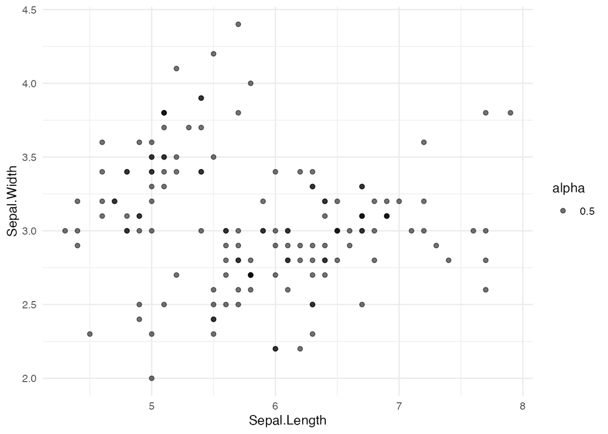

```r
library(tidyverse)
plot_points <- function(data, x, y, alpha){
  ggplot(data = data, aes_string(x = x, y = y, alpha = alpha))+
    geom_point() +
    theme_minimal()
}

plot_points(data = iris,
            x = "Sepal.Length",
            y = "Sepal.Width",
            alpha = 0.5)
```

これでもいいといえばいいのですが、Tidyevalらしくするなら、`enquo()`でクオージャーを作ってクオートとして、必要な部分でアンクオートするほうが自然に見える。

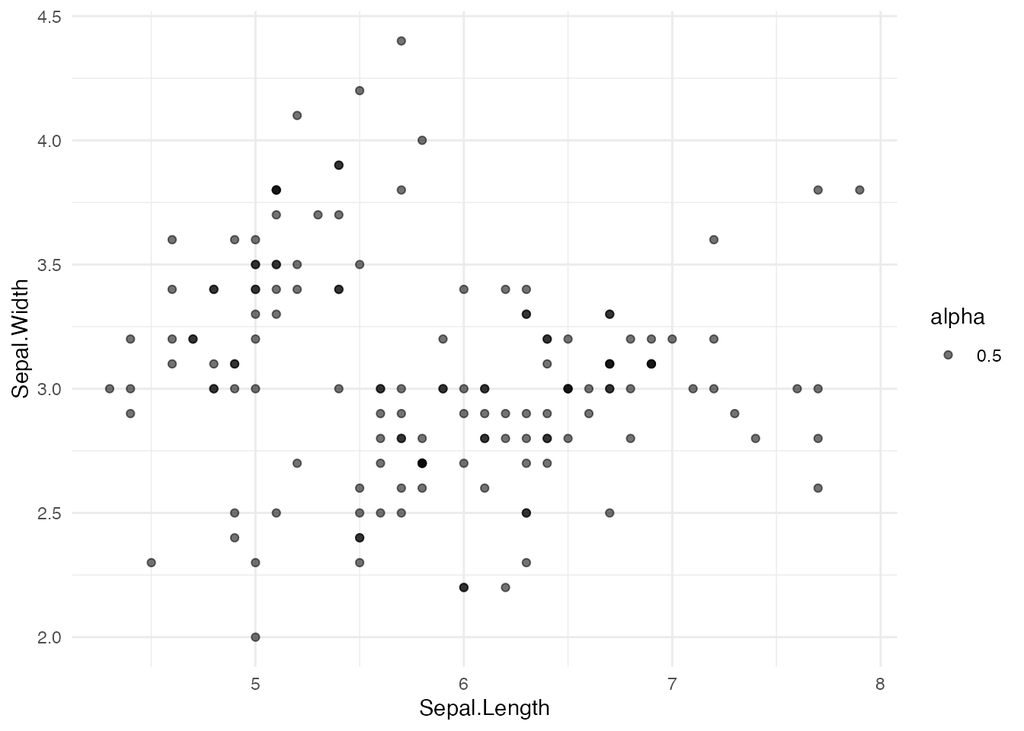

```r
plot_points_tidyeval <- function(data, x, y, alpha){

  x_enq <- enquo(x)
  y_enq <- enquo(y)

  ggplot(data = data, aes(x = !!x_enq, y = !!y_enq, alpha = alpha))+
    geom_point() +
    theme_minimal()
}

plot_points_tidyeval(data = iris,
                     x = Sepal.Length,
                     y = Sepal.Width,
                     alpha = 0.5)
```

## `facet_grid()`

`facet_grid()`は少し戸惑う。`vars()`という関数は、`facet_grid()`の`~`のヘルパ関数。`facet`を`enquo()`して、アンクオートしてから`vars()`することになる。

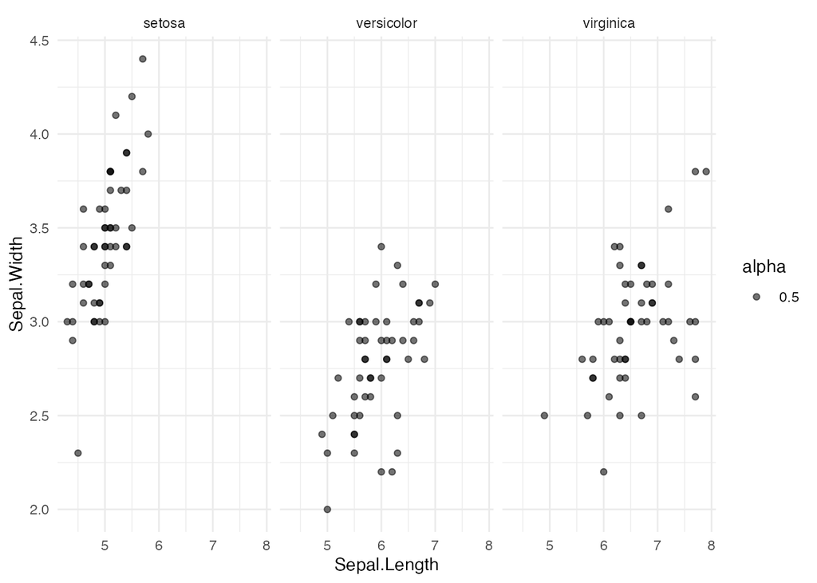

```r
plot_points_tidyeval <- function(data, x, y, alpha, facet){

  x_enq <- enquo(x)
  y_enq <- enquo(y)
  facet_enq <- enquo(facet)

  ggplot(data, aes(x = !!x_enq, y = !!y_enq, alpha = alpha))+
    geom_point()+
    theme_minimal()+
    facet_grid(cols = vars(!!facet_enq))
  }

iris %>%
  plot_points_tidyeval(
    x = Sepal.Length,
    y = Sepal.Width,
    facet = Species,
    alpha = 0.5
  )
```

`facet_wrap()`は外部クオートしておけば、アンクオートする必要もなかったりする。`vars()`って、これまでのブログでも外部クオートするために便利な関数だと思ってたけど、どうやら認識に誤りがあるようです…(備考に追加したので参照)。

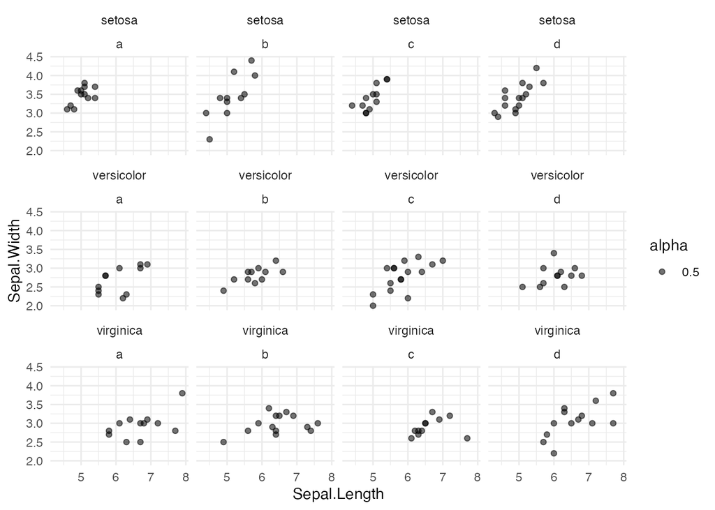

```r
plot_points_tidyeval <- function(data, x, y, alpha, facet){

  x_enq <- enquo(x)
  y_enq <- enquo(y)

  ggplot(data = data, aes(x = !!x_enq, y = !!y_enq, alpha = alpha))+
    geom_point() +
    theme_minimal() +
    # facet_wrap() doesn't need !!!(bang-bang-bang)
    facet_wrap(facet)
  }

iris %>%
  mutate(pot = sample(c("a", "b", "c", "d"), 150, replace = TRUE)) %>%
  plot_points_tidyeval(
    data = .,
    x = Sepal.Length,
    y = Sepal.Width,
    alpha = 0.5,
    facet = vars(Species, pot)
  )
```

これは、先程の内容をかき直しただけ。`...`で変数を`facet_wrap()`に流し、`vars()`を使う。

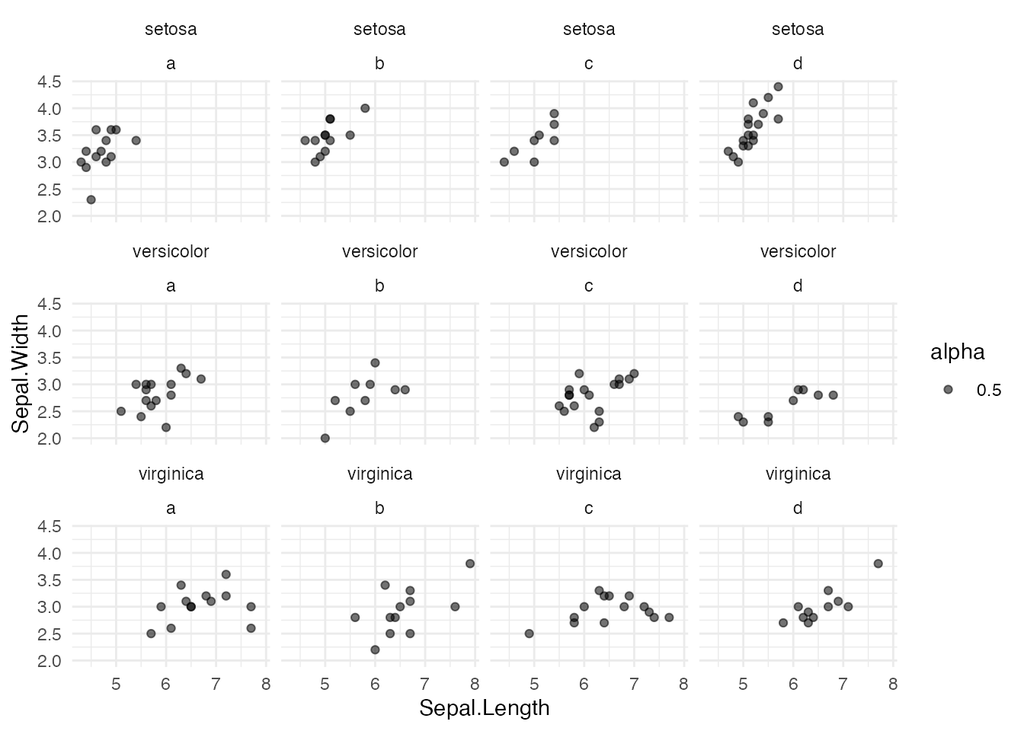

```r
plot_points_tidyeval <- function(data, x, y, alpha, ...){

  x_enq <- enquo(x)
  y_enq <- enquo(y)

  ggplot(data = data, aes(x = !!x_enq, y = !!y_enq, alpha = alpha)) +
    geom_point() +
    theme_minimal() +
    facet_wrap(vars(...))
}

iris %>%
  mutate(pot = sample(c("a", "b", "c", "d"), 150, replace = TRUE)) %>%
  plot_points_tidyeval(
    data = .,
    x = Sepal.Length,
    y = Sepal.Width,
    alpha = 0.5,
    Species, pot
  )
```

はぁ…TidyEval難しす…

## 備考

`_at`などのスコープ付き動詞は、引数として`...`を使用しない。`summarise_at(vars(col1, col2,...), list(fun1, fun2,...))`みたいな形で、`vars()`を使用する。`summarise_at()`が期待するものは、`vars()`です。なので、`var()`を渡す必要があって、他のモノとは違って`!!!(bang-bang-bang)`する必要はなかったりする。`facet_grid()`の`~`もそういうことだと思う…[ggplot2 3.0.0](https://www.tidyverse.org/blog/2018/07/ggplot2-3-0-0/)とか見てください。

```
g_sum <- function(data, grouped_vars, summary_vars, summary_funs) {

  data %>%
    group_by(!!!grouped_vars) %>%
    summarise_at(summary_vars, summary_funs)

}

mtcars %>%
  g_sum(
    grouped_vars = vars(gear, carb),
    summary_vars = vars(mpg, cyl, disp),
    summary_funs = list(mean = mean, median = median)
  )

# A tibble: 11 x 8
# Groups:   gear [3]
    gear  carb mpg_mean cyl_mean disp_mean mpg_median cyl_median disp_median
   <dbl> <dbl>    <dbl>    <dbl>     <dbl>      <dbl>      <dbl>       <dbl>
 1     3     1     20.3     5.33     201.        21.4          6       225
 2     3     2     17.2     8        346.        17.1          8       339
 3     3     3     16.3     8        276.        16.4          8       276.
 4     3     4     12.6     8        416.        13.3          8       440
 5     4     1     29.1     4         84.2       29.8          4        78.8
 6     4     2     24.8     4        121.        23.6          4       131.
 7     4     4     19.8     6        164.        20.1          6       164.
 8     5     2     28.2     4        108.        28.2          4       108.
 9     5     4     15.8     8        351         15.8          8       351
10     5     6     19.7     6        145         19.7          6       145
11     5     8     15       8        301         15            8       301
```

調べてみたけども、ちゃんとなんでそうなのか理解しないといけないな…